# Lab 13: More Regular Expressions

Stat 133, Spring 2022

### Learning Objectives

> - String manipulation
> - Base R functions for strings
> - Work with the package `"stringr"`
> - String manipulation
> - More practice with regular expressions

### General Instructions

- Write your descriptions, explanations, and code in an `Rmd` (R markdown) file.
- Name this file as `lab13-first-last.Rmd`, where `first` and `last` are your first and last names (e.g. `lab13-gaston-sanchez.Rmd`).
- Knit your `Rmd` file as an html document (default option).
- Submit your `Rmd` and `html` files to bCourses, in the corresponding lab assignment.

```r
library(tidyverse)
```

## Data “Emotion in Text”

You’ll be working with the data file `text-emotion.csv` available in bCourses, in the folder containing this `Rmd`.

The original source is the data set “Emotion in Text” from the website Crowd Flower Data for Everyone https://www.crowdflower.com/data-for-everyone/

```r
# assuming data file is in the same directory of your Rmd
tweets <- read.csv('text-emotion.csv', stringsAsFactors = FALSE)
```

The file contains four columns:

- `tweet_id`: tweet identifier
- `sentiment`: class or sentiment label
- `author`: username author of the tweet
- `content`: content of the tweet

Also, while you work on this lab you may want to look at the cheat-sheets for:

- `"stringr"` cheatsheet (see bCourses)
- regular-expressions cheatsheet (see bCourses)

### 1.1) Author (usernames)

According to Twitter, usernames:

- cannot be longer than 15 characters
- can only contain alphanumeric characters (letters A-Z, numbers 0-9) with the exception of underscores (i.e. cannot contain any symbols, dashes or spaces, except underscores)
- *If you want to know more about twitter usernames, visit:*

https://help.twitter.com/en/managing-your-account/twitter-username-rules

### 1.2) Your Turn: author names

Confirm that the values in column `author` follow each of the rules for valid usernames:

1. No longer than 15 characters *(if you find usernames longer than 15 characters, display them)*

```r
tweets <- read.csv('text-emotion.csv', stringsAsFactors = FALSE)

length(tweets$author[str_length(tweets$author) > 15])
```

```
## [1] 0
```

2. Contain alphanumeric characters and underscores. If you find usernames containing other symbols, display them. *Hint*: The non-word character class is `"\\W"` is your friend.

```r
tweets$author[str_which(tweets$author, "\\W")]
```

```
## [1] "4040-10-01"
```

3. What is the number of characters of the shortest usernames? And what are the names of these authors? *(write commands to answer these questions)*

```r
min(str_length(tweets$author))
```

```
## [1] 2
```

```r
tweets$author[str_length(tweets$author) == 2]
```

```
## [1] "kk" "xz" "zk" "zk" "ms" "c5"
```

### 2) Your Turn: Various Symbols and Strings

Tweets contain all sorts of symbols: `!`, `?`, `%`, `$`, etc.

1. How many tweets contain at least one caret symbol `"^"` *(write a command to answer this question)*.

```r
sum(str_detect(tweets$content, "\\^"))
```

```
## [1] 40
```

2. How many tweets contain three or more consecutive dollar symbols `"$"` *(write a command to answer this question)*.

```r
sum(str_detect(tweets$content, "[$][$][$]"))
```

```
## [1] 7
```

3. How many tweets do NOT contain the characters `"a"` or `"A"` *(write a command to answer this question)*.

```r
sum(!str_detect(tweets$content, "[aA]"))
```

```
## [1] 1875
```

4. Display the first 10 elements of tweets that do NOT contain the characters `"a"` or `"A"` *(write a command to answer this question)*.

```r
twts <- tweets$content[!str_detect(tweets$content, "[aA]")]

head(twts, n = 10)
```

```
##  [1] "Hmmm. http://www.djhero.com/ is down"
##  [2] "Got the news"
##  [3] "I missed the bl***y bus!!!!!!!!"
##  [4] "I need skott right now"
##  [5] "I miss Voobys!"
##  [6] "i'm so tired"
##  [7] "miss 16'th"
##  [8] "my sole supporter is not my sole supporter"
##  [9] "@Emilyyy16 urgh stop it guys"
## [10] "I miss my puppy"
```

5. Number of exclamation symbols `"!"`: compute a vector with the number of exclamation symbols in each tweet, and display its `summary()`.

```r
summary(str_count(tweets$content, "!"))
```

```
##    Min. 1st Qu.  Median    Mean 3rd Qu.    Max.
##  0.0000  0.0000  0.0000  0.5504  1.0000 76.0000
```

6. What’s the tweet (content) with the largest number of exclamation symbols `!`? Display its content. *(write a command to answer this question)*

```r
tweets$content[str_count(tweets$content, '!') == max(str_count(tweets$content, '!'))]
```

```
## [1] "WHAHHH!!!!!!!!!!!!!!!!!!!!!!!!!!!!!!!!!!!! NOO!!!!!!!!!!!!!!!!!!!!!!!!!!!!!!!!!!!!!!!!"
```

### 3) Your Turn: Valid Hashtags

People use the hashtag symbol `#` before a relevant keyword or phrase in their tweet to categorize those Tweets and help them show more easily in Twitter search. According to Twitter, hashtags cannot contain spaces or punctuation symbols, and cannot start with or use only numbers.

1. Count the number of (valid) hashtags in the tweet contents, and display a frequency `table()` of such counts.

```r
tab <- table(str_count(tweets$content, '#[[:alpha:]][[:alnum:]]+'))
```

2. Display such frequencies, and make a barplot of these counts (i.e. number of tweets with 0 hashtags, with 1 hashtag, with 2 hashtags, etc).

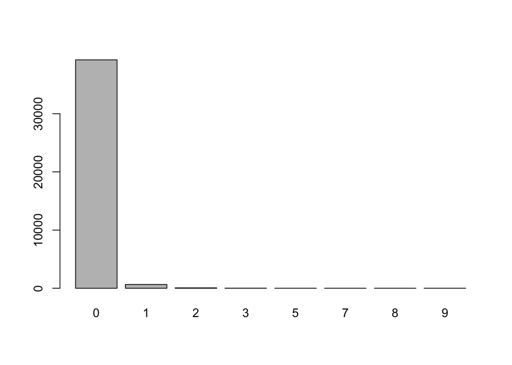

```r
barplot(tab)
```

3. What is the average length of the unique hashtags? Do not count the hash `#` symbol when determining the length.

```r
summary(str_count(unique(unlist(str_extract_all(tweets$content, '#[[:alpha:]][[:alnum:]]+'))))) - 1
```

```
##    Min. 1st Qu.  Median    Mean 3rd Qu.    Max.
##    2.00    5.00    8.00    8.06   10.00   34.00
```

4. What is the most common length (i.e. the mode) of the hashtags?

```r
table(str_count(unique(unlist(str_extract_all(tweets$content, '#[[:alpha:]][[:alnum:]]+')))) - 1)
```

```
##
##  2  3  4  5  6  7  8  9 10 11 12 13 14 15 16 17 18 19 20 21 22 34
## 10 43 63 48 50 55 59 51 41 31 25 15 18 14  7  6  3  2  2  2  1  1
```

### 4) Tweets with OMG and omg

How many tweets contain the *individual* strings `"omg"` or `"OMG"` *(write a command to answer this question)*. For example:

- `omg I just saw them again` (this would be a match)
- `OMG I just saw them again` (this would be a match)
- `I just saw them again omg` (this would be a match)
- `I just saw them again OMG` (this would be a match)
- `I just saw them omg can't believe it` (this would be a match)
- `I just saw them OMG can't believe it` (this would be a match)
- `omg: I just saw them again` (this would NOT be a match)
- `OMG,I just saw them again` (this would NOT be a match)
- `I just saw them again omg!!!` (this would NOT be a match)
- `I just saw them again omgomgomg` (this would NOT be a match)
- `I just saw them again lol-omg!!!` (this would NOT be a match)

```r
sum(str_detect(tweets$content, '^(omg|OMG)\\s | \\s(omg|OMG)\\s | \\s(omg|OMG)$'))
```

```
## [1] 2
```

### 5.2) Your Turn: Average Patterns by Sentiment

Write code to create (and display) a table (e.g. data frame, tibble, matrix) in which the rows correspond to the different types of sentiments, and the columns correspond to:

1. average number of lower case letters
2. average number of upper case letters
3. average number of digits
4. average number of punctuation symbols
5. average number of spaces

*Hint: POSIX character classes are your friends.*

```r
tweets %>%
  group_by(sentiment) %>%
  summarise(avg_low = mean(str_count(content, '[[:lower:]]')),
            avg_up = mean(str_count(content, '[[:upper:]]')),
            dig = mean(str_count(content, '[[:digit:]]')),
            punct = mean(str_count(content, '[[:punct:]]')),
            spaces = mean(str_count(content, '[[:space:]]'))
            )
```

```
## # A tibble: 13 × 6
##    sentiment  avg_low avg_up   dig punct spaces
##    <chr>        <dbl>  <dbl> <dbl> <dbl>  <dbl>
##  1 anger         55.8   3.55 0.609  4.03   13.6
##  2 boredom       53.9   2.85 0.598  3.78   13.0
##  3 empty         46.9   2.65 0.530  3.72   10.8
##  4 enthusiasm    53.4   3.90 0.527  4.05   12.9
##  5 fun           58.4   3.78 0.565  4.56   13.9
##  6 happiness     54.2   3.70 0.553  4.21   12.9
##  7 hate          56.4   3.68 0.490  4.17   13.8
##  8 love          53.1   3.89 0.495  4.22   12.7
##  9 neutral       46.8   2.81 0.581  3.56   10.7
## 10 relief        55.9   3.00 0.489  3.82   13.3
## 11 sadness       54.1   3.13 0.456  3.88   13.3
## 12 surprise      54.3   3.44 0.573  4.46   12.9
## 13 worry         55.6   3.10 0.506  3.93   13.6
```